# Temporal_trend

2022-10-19

This document includes analysis of all temporal trends in the data. This includes: - Absolute population abundance - Carrying capacity - Sex ratio - Age ratio

# Prepare workspace

Load required packages

```r
library(ggplot2)
library(hyenaR)
library(dplyr)
library(here)
library(spaMM)
spaMM.options(nb_cores=10) ## CHECK WITH htop BEFORE USING TOO MANY
library(doSNOW)
library(DHARMa)
library(lubridate)
```

Define which simulation type we’re using

```r
start_year  <- 1997
end_year    <- 2022
growth_period_until <- 2011
scale <- "year"
```

# Extract data

Extract estimated K

```r
## Time-varying carrying capacity (Kt)
if (!file.exists(here::here("./data/Kplot_data.RDS"))) {
  ## EXTRACT ESTIMATED K
  years <- start_year:end_year

  pb_yr <- progress::progress_bar$new(total = length(years))

  Kplot_data <- purrr::map_df(.x = years,
                              .f = function(year){

                                pb_yr$tick()

                                txt_files <- list.files(here(paste0("./STEP1_estimateK/", year)),
                                                        pattern = ".txt", full.names = TRUE)

                                allsims <- purrr::map_df(.x = txt_files,
                                                         .f = function(filepath){

                                                           readr::read_delim(filepath, show_col_types = FALSE, lazy = FALSE) %>%
                                                             dplyr::mutate(sim = stringr::str_extract(filepath, "(?<=_)[0-9]+(?=.txt)"))

                                                         })

                                estK <- allsims %>%
                                  dplyr::group_by(.data$sim) %>%
                                  dplyr::mutate(start_pop = first(pop_size)) %>%
                                  dplyr::slice(ceiling(dplyr::n()/2):dplyr::n()) %>%
                                  dplyr::summarise(K = median(.data$pop_size),
                                                   start_size = first(start_pop))

                                plot_data <- estK %>%
                                  dplyr::summarise(year = year,
                                                   globalK = median(.data$K),
                                                   lower = min(.data$K),
                                                   upper = max(.data$K),
                                                   points = list(data.frame(pop_size = .data$K,
                                                                            start_pop = .data$start_size)))

                                return(plot_data)

                              })

  saveRDS(Kplot_data, here::here("./data/Kplot_data.RDS"))
} else {
  Kplot_data <- readRDS(here::here("./data/Kplot_data.RDS"))
}
```

Extract real pop data over time at 1 month and 6mo intervals.

```r
### GENERATED IN STEP0_prepare_data/demographic_data.R
if (scale == "year"){
  real_pop <- readRDS(here::here("./data/Nplot_data_year.RDS"))
  real_pop_separate <- readRDS(here::here("./data/Nplot_data_separate_year.RDS"))
} else if (scale == "month"){
  real_pop <- readRDS(here::here("./data/Nplot_data_month.RDS"))
  real_pop_separate <- readRDS(here::here("./data/Nplot_data_separate_1month.RDS"))
}
```

Prepare sex and age ratio data

```r
### Calculate sex ratio (male/all females)
ratios <- real_pop_separate %>%
  mutate(sex_ratio = ad_male/(ad_male + ad_fem),
         age_ratio = young/(young + ad_male + ad_fem)) %>%
  tidyr::pivot_longer(cols = sex_ratio:age_ratio)
```

# Population abundance (N)

## Describe growth period

When were adult numbers highest in first growth period?

```r
real_pop_separate %>%
  mutate(total_ad = ad_male+ad_fem) %>%
  filter(year(date) < 2015) %>%
  filter(total_ad == max(total_ad))
```

```
## # A tibble: 1 × 5
##   date       young ad_male ad_fem total_ad
##   <date>     <int>   <int>  <int>    <int>
## 1 2011-01-01   322     200    232      432
```

## Trend in whole period

```r
real_pop <- real_pop |>
  mutate(year = lubridate::year(date),
         n = 1:n())

N_model <- fitme(pop_size ~ year + AR1(1|n), data = real_pop, family = "poisson")
N_model_null <- fitme(pop_size ~ 1 + AR1(1|n), data = real_pop, family = "poisson")

summary(N_model)
```

```
## formula: pop_size ~ year + AR1(1 | n)
## Estimation of corrPars and lambda by ML (p_v approximation of logL).
## Estimation of fixed effects by ML (p_v approximation of logL).
## Estimation of lambda by 'outer' ML, maximizing logL.
## family: poisson( link = log )
##  ------------ Fixed effects (beta) ------------
##              Estimate Cond. SE t-value
## (Intercept) -64.74843 23.63455  -2.740
## year          0.03522  0.01176   2.994
##  --------------- Random effects ---------------
## Family: gaussian( link = identity )
##                    --- Correlation parameters:
##   1.ARphi
## 0.8988488
##            --- Variance parameters ('lambda'):
## lambda = var(u) for u ~ Gaussian;
##    n  :  0.04911
## # of obs: 27; # of groups: n, 27
##  ------------- Likelihood values  -------------
##                         logLik
## logL       (p_v(h)): -144.0469
```

```r
LRT(N_model, N_model_null)
```

```
##      chi2_LR df    p_value
## p_v 5.400545  1 0.02013047
```

```r
confint(N_model, parm = "year")
```

```
##  lower year  upper year
## 0.007211666 0.063003987
```

## Trend during growth period

```r
real_pop_growth <- real_pop |>
  filter(year <= growth_period_until)

N_model <- fitme(pop_size ~ year + AR1(1|n), data = real_pop_growth, family = "poisson")
N_model_null <- fitme(pop_size ~ 1 + AR1(1|n), data = real_pop_growth, family = "poisson")

summary(N_model)
```

```
## formula: pop_size ~ year + AR1(1 | n)
## Estimation of corrPars and lambda by ML (p_v approximation of logL).
## Estimation of fixed effects by ML (p_v approximation of logL).
## Estimation of lambda by 'outer' ML, maximizing logL.
## family: poisson( link = log )
##  ------------ Fixed effects (beta) ------------
##               Estimate  Cond. SE t-value
## (Intercept) -143.67878 12.048881  -11.92
## year           0.07469  0.006013   12.42
##  --------------- Random effects ---------------
## Family: gaussian( link = identity )
##                    --- Correlation parameters:
##   1.ARphi
## 0.6567311
##            --- Variance parameters ('lambda'):
## lambda = var(u) for u ~ Gaussian;
##    n  :  0.00347
## # of obs: 16; # of groups: n, 16
##  ------------- Likelihood values  -------------
##                         logLik
## logL       (p_v(h)): -73.84703
```

```r
LRT(N_model, N_model_null)
```

```
##      chi2_LR df      p_value
## p_v 21.66888  1 3.240058e-06
```

```r
confint(N_model, parm = "year")
```

```
## lower year upper year
## 0.06161629 0.09223260
```

## Trend after growth period

```r
real_pop_aftergrowth <- real_pop |>
  filter(year > growth_period_until)

N_model <- fitme(pop_size ~ year + AR1(1|n), data = real_pop_aftergrowth, family = "poisson")
N_model_null <- fitme(pop_size ~ 1 + AR1(1|n), data = real_pop_aftergrowth, family = "poisson")

summary(N_model)
```

```
## formula: pop_size ~ year + AR1(1 | n)
## Estimation of corrPars and lambda by ML (p_v approximation of logL).
## Estimation of fixed effects by ML (p_v approximation of logL).
## Estimation of lambda by 'outer' ML, maximizing logL.
## family: poisson( link = log )
##  ------------ Fixed effects (beta) ------------
##             Estimate Cond. SE t-value
## (Intercept) 42.81414 29.67293   1.443
## year        -0.01807  0.01471  -1.228
##  --------------- Random effects ---------------
## Family: gaussian( link = identity )
##                    --- Correlation parameters:
## 1.ARphi
## 0.50611
##            --- Variance parameters ('lambda'):
## lambda = var(u) for u ~ Gaussian;
##    n  :  0.01181
## # of obs: 11; # of groups: n, 11
##  ------------- Likelihood values  -------------
##                         logLik
## logL       (p_v(h)): -60.72114
```

```r
LRT(N_model, N_model_null)
```

```
##      chi2_LR df   p_value
## p_v 1.287668  1 0.2564782
```

```r
confint(N_model, parm = "year")
```

```
##  lower year  upper year
## -0.05400299  0.01872185
```

## Fluctuation in N following growth

How can we describe the period after growth period?

```r
postgrowth_data <- real_pop %>%
  ## Use 1st May b/c we calculated over whole months
  ## Numbers are similar.
  filter(lubridate::year(date) > growth_period_until)

median(postgrowth_data$pop_size)
```

```
## [1] 589
```

```r
range(postgrowth_data$pop_size)
```

```
## [1] 454 712
```

# Carrying capacity (K)

## Years of decline

When did K show sharp declines (we define here as <= 80% of previous value)

```r
Kplot_data %>%
  filter(year <= end_year) %>%
  reframe(prop_change = lead(globalK)/globalK,
          year = year) %>%
  filter(!is.na(prop_change) & prop_change <= 0.8)
```

```
## # A tibble: 4 × 2
##   prop_change  year
##         <dbl> <int>
## 1       0.792  2001
## 2       0.799  2010
## 3       0.525  2017
## 4       0.688  2018
```

## Descriptive stats

Range and SD of K

```r
range(Kplot_data$globalK)
```

```
## [1] 260 827
```

```r
sd(Kplot_data$globalK)
```

```
## [1] 140.4305
```

## Kt in full period

Estimate over the full period (because we’re not just focusing in growth anymore)

```r
Kplot_data_sub <- Kplot_data %>%
  filter(year <= end_year) |>
  mutate(n = 1:n())

poisson_data <- Kplot_data_sub %>%
  mutate(globalK = as.integer(globalK))
```

#### Model 1: Poisson

```r
K_model1 <- fitme(globalK ~ year + AR1(1|n), data = poisson_data, family = "poisson")
```

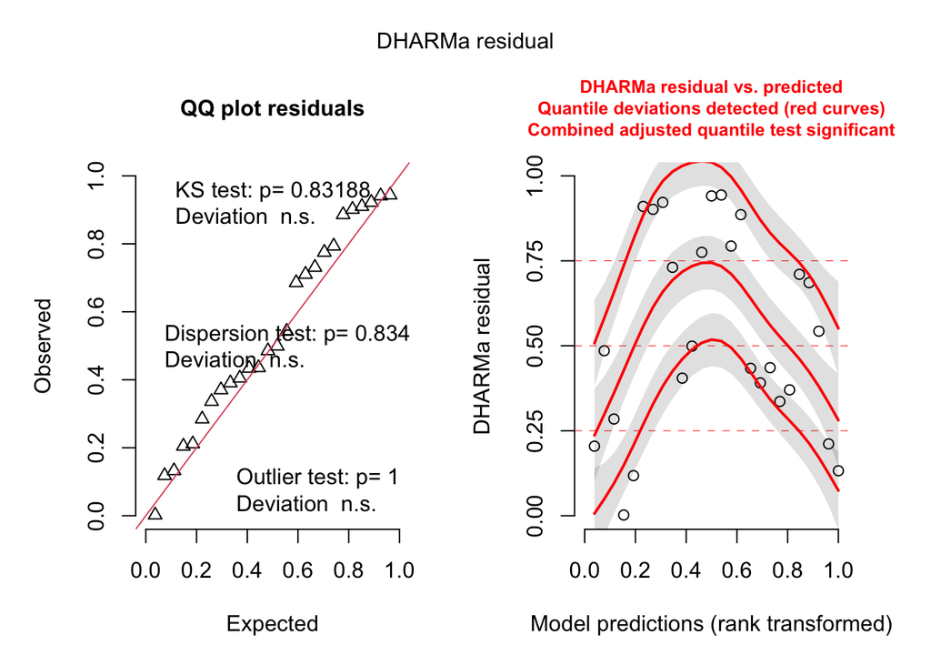

```r
K_model1_resid <- simulateResiduals(K_model1, n = 1000, seed = 123)

plot(K_model1_resid)
```

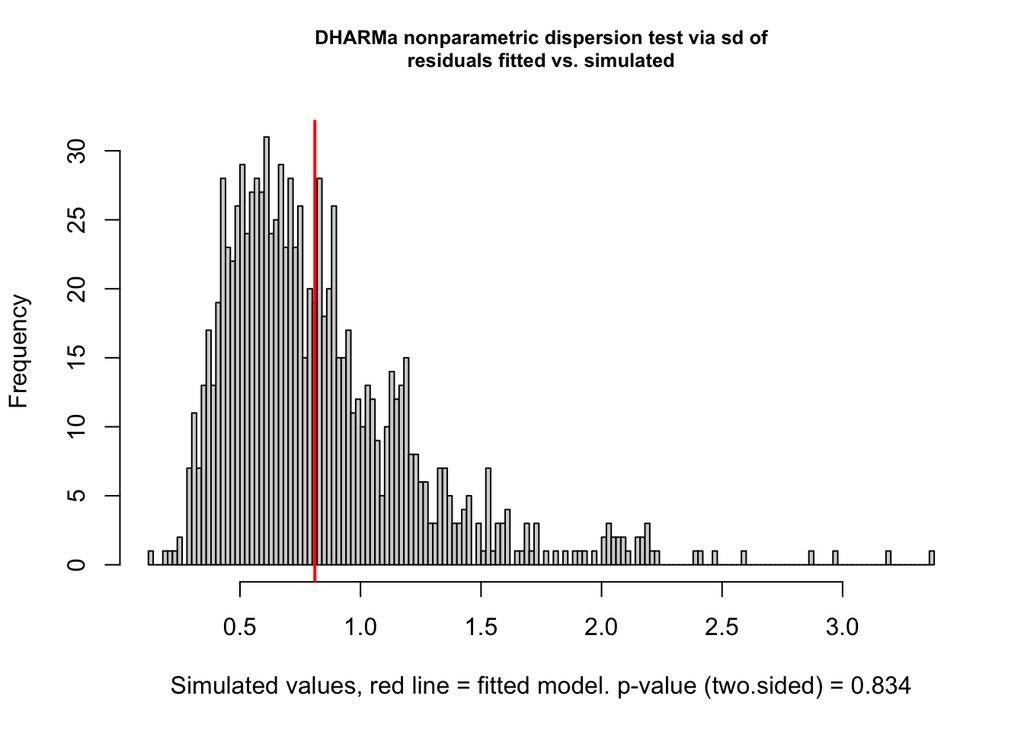

```
##
##  DHARMa nonparametric dispersion test via sd of residuals fitted vs.
##  simulated
##
## data:  simulationOutput
## dispersion = 0.98188, p-value = 0.834
## alternative hypothesis: two.sided
```

```r
DHARMa::testDispersion(K_model1_resid)
```

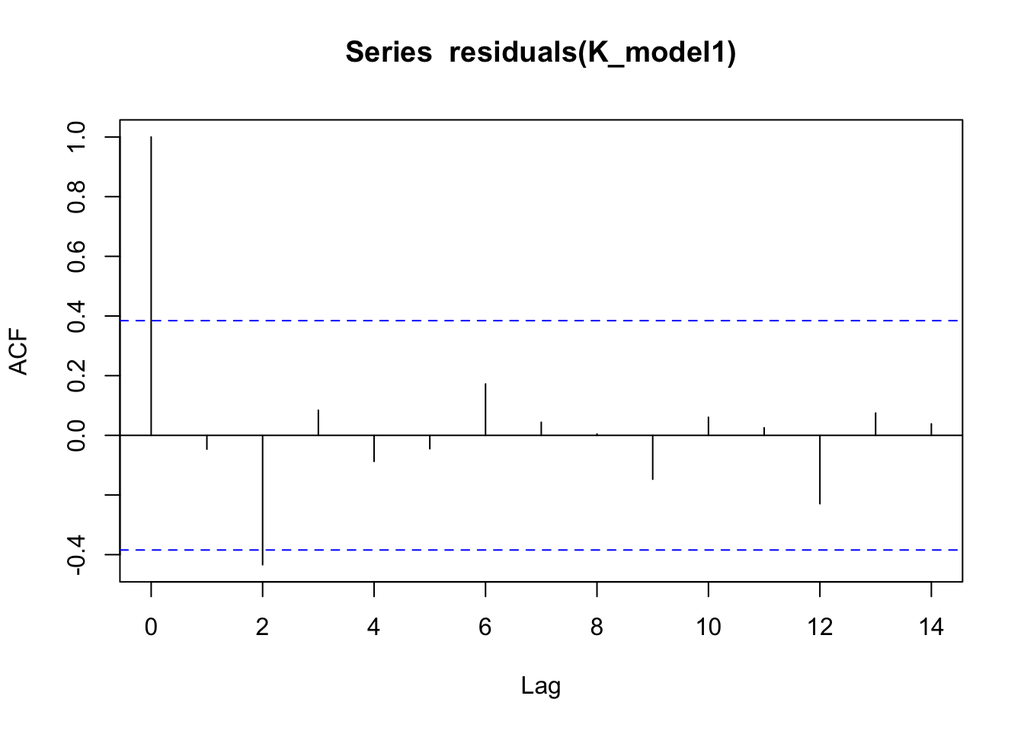

```r
acf(residuals(K_model1))
```

Temporal auto-correlation not too serious. For parsimony maybe easier to accept this and no need to fit AR1 term (which causes problems)

#### Model 2: Gaussian

Could we achieve the same thing just using Gaussian model?

```r
## Use the same Poisson data for AIC are comparable
K_model2 <- fitme(globalK ~ year + AR1(1|n), data = poisson_data, family = "gaussian")
```

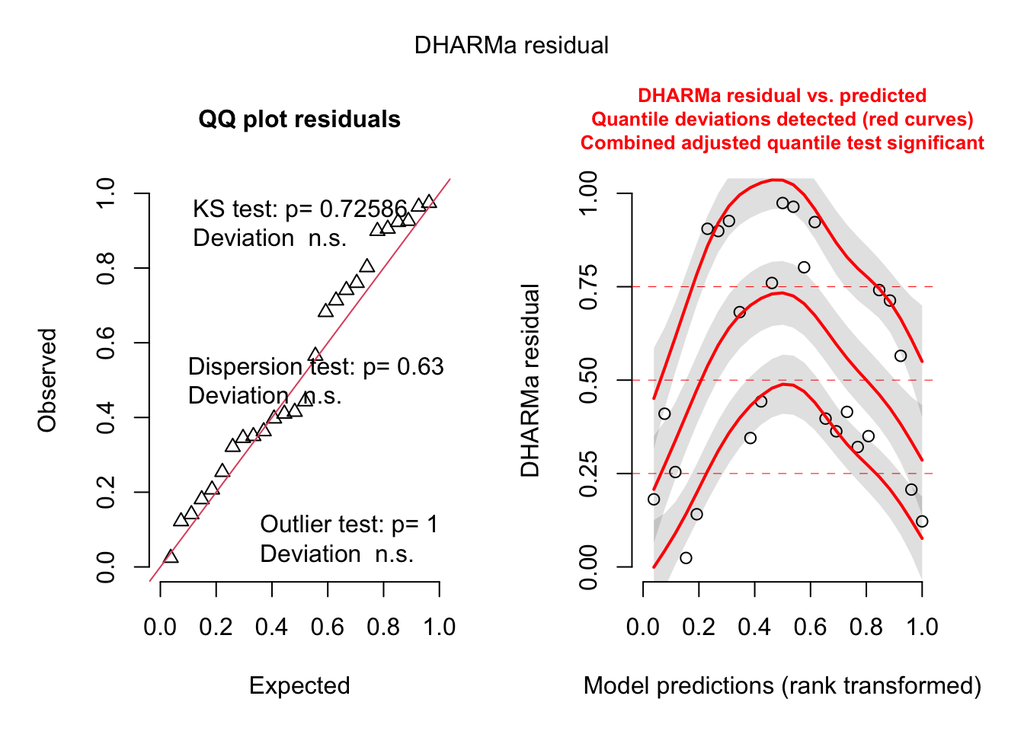

```r
K_model2_resid <- simulateResiduals(K_model2, n = 1000, seed = 123)

plot(K_model2_resid)
```

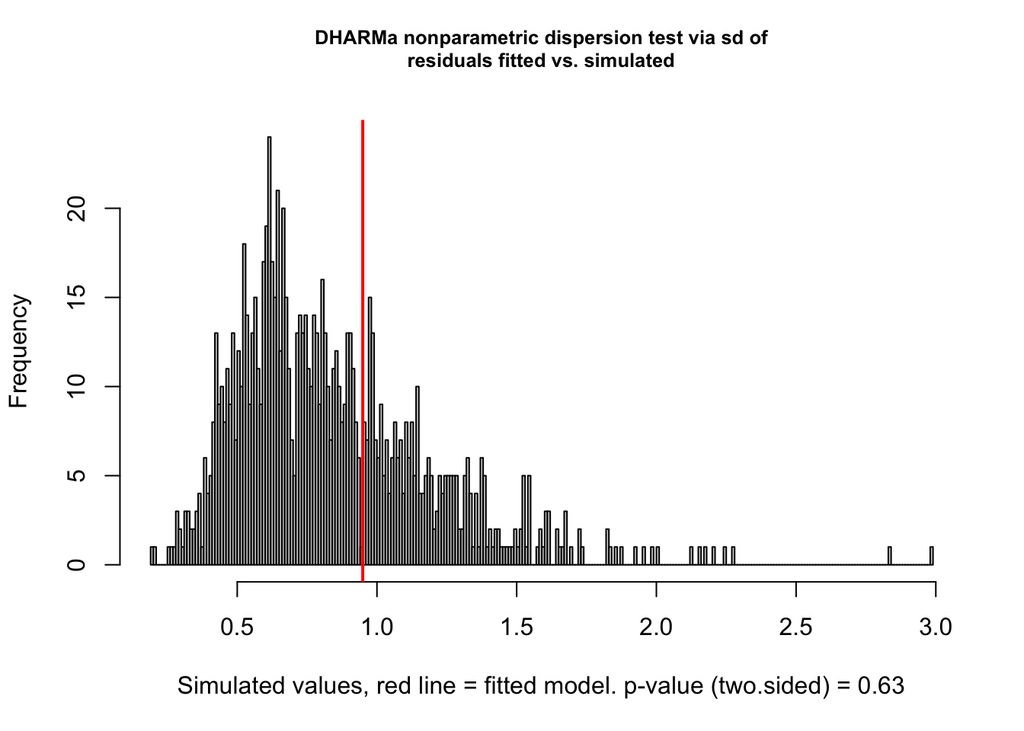

```
##
##  DHARMa nonparametric dispersion test via sd of residuals fitted vs.
##  simulated
##
## data:  simulationOutput
## dispersion = 1.1314, p-value = 0.63
## alternative hypothesis: two.sided
```

```r
DHARMa::testDispersion(K_model2_resid)
```

Dispersion issue fixed…

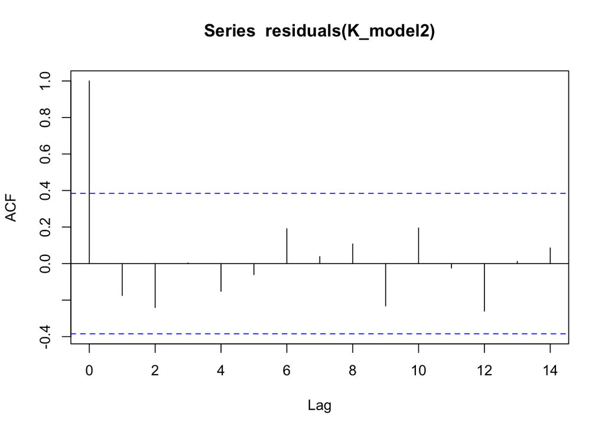

```r
acf(residuals(K_model2))
```

Temporal auto-correlation seems ok.

#### Model 3: Negative-binomial

```r
K_model3 <- fitme(globalK ~ year + AR1(1|n), data = poisson_data, family = spaMM::negbin2())
```

```
## qu = 0.25, log(sigma) = -3.971549 : outer Newton did not converge fully.
```

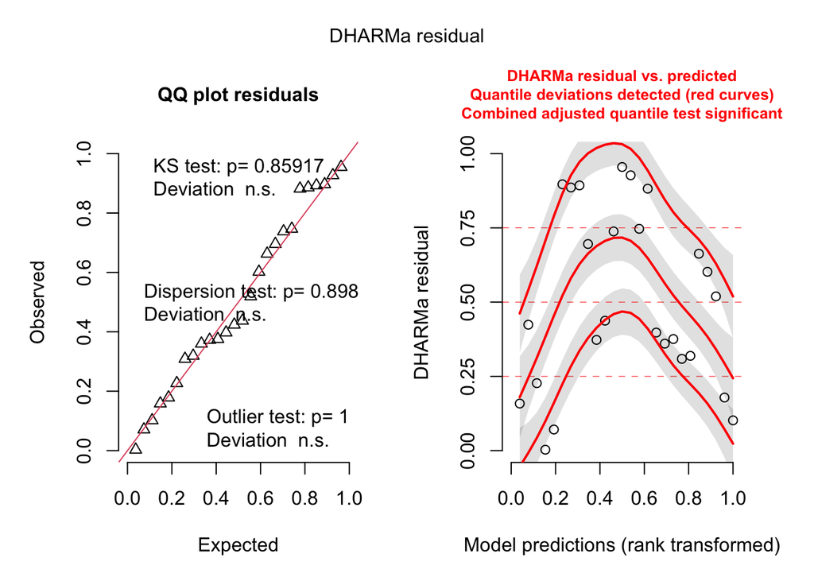

```r
K_model3_resid <- simulateResiduals(K_model3, n = 1000, seed = 123)

plot(K_model3_resid)
```

Uniformity better, quantiles still a bit messy.

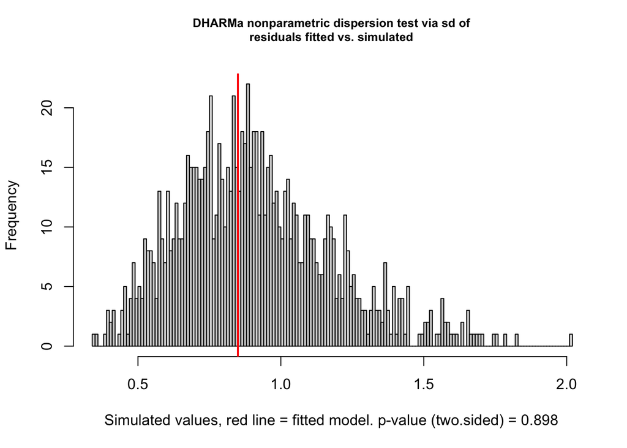

```
##
##  DHARMa nonparametric dispersion test via sd of residuals fitted vs.
##  simulated
##
## data:  simulationOutput
## dispersion = 0.93467, p-value = 0.898
## alternative hypothesis: two.sided
```

```r
DHARMa::testDispersion(K_model3_resid)
```

Dispersion issue fixed…

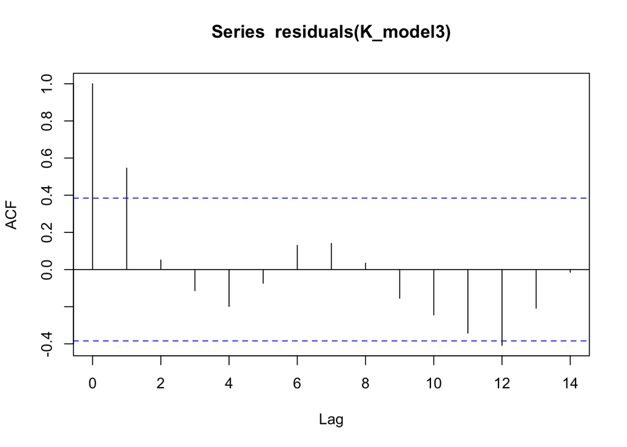

```r
acf(residuals(K_model3))
```

Temporal auto-correlation seems not too bad.

#### Compare possible models

```r
do.call(dplyr::bind_rows, purrr::map(.x = list(K_model1, K_model2, K_model3),
                                     .f = spaMM::AIC.HLfit)) %>%
  mutate(model = seq(1:n())) %>%
  select(model, everything()) %>%
  janitor::clean_names() %>%
  arrange(marginal_aic)
```

```
## # A tibble: 3 × 5
##   model marginal_aic conditional_aic dispersion_aic effective_df
##   <int>        <dbl>           <dbl>          <dbl>        <dbl>
## 1     2         327.            24.3           323.     0.000208
## 2     1         329.           264.            325.     1.44
## 3     3         340.           336.            336.    24.0
```

#### Model results and CI

LRT to compare model to null

```r
global_mod <- fitme(globalK ~ year, data = poisson_data, family = spaMM::negbin2())
null_mod   <- fitme(globalK ~ 1, data = poisson_data, family = spaMM::negbin2())

summary(global_mod)
```

```
## formula: globalK ~ year
## Estimation of fixed effects by ML.
## Estimation of NB_shape by 'outer' ML, maximizing logL.
## family: negbin2(shape=18.27)( link = log )
##  ------------ Fixed effects (beta) ------------
##             Estimate  Cond. SE t-value
## (Intercept) 26.54312 12.483208   2.126
## year        -0.01003  0.006212  -1.615
##  ------------- Likelihood values  -------------
##                         logLik
## logL               : -164.8943
```

```r
## #Asymptotic pvalue for consistency
LRT(global_mod, null_mod)
```

```
##      chi2_LR df   p_value
## p_v 2.215839  1 0.1366008
```

```r
# LRT_result_gaussian <- LRT(global_mod, null_mod, boot.repl = 999, nb_cores = 10, seed = 123)
# data.frame(basic = LRT_result_gaussian$basicLRT$p_value, bartlett = LRT_result_gaussian$BartBootLRT$p_value, bootstrap = LRT_result_gaussian$rawBootLRT$p_value)
```

Summary of full model

```r
summary(global_mod)
```

```
## formula: globalK ~ year
## Estimation of fixed effects by ML.
## Estimation of NB_shape by 'outer' ML, maximizing logL.
## family: negbin2(shape=18.27)( link = log )
##  ------------ Fixed effects (beta) ------------
##             Estimate  Cond. SE t-value
## (Intercept) 26.54312 12.483208   2.126
## year        -0.01003  0.006212  -1.615
##  ------------- Likelihood values  -------------
##                         logLik
## logL               : -164.8943
```

CI of year term

```r
spaMM::confint.HLfit(global_mod, parm = "year")
```

```
##   lower year   upper year
## -0.023481431  0.003388256
```

Fixef term

```r
fixef(global_mod)[2]
```

```
##        year
## -0.01003492
```

## Ktc in full period

```r
if (file.exists(here::here("./data/Kplot_clan_data.RDS"))) {
  Kplot_data_byclan <- readRDS(here::here("./data/Kplot_clan_data.RDS"))
} else {

  ## EXTRACT ESTIMATED
  years <- start_year:end_year

  pb_yr <- progress::progress_bar$new(total = length(years))

  Kplot_data <- purrr::map_df(.x = years,
                              .f = function(year, folder_name){

                                pb_yr$tick()

                                txt_files <- list.files(here(paste0("~/data/simulation_results/analysis/STEP1_estimateK/", year)),
                                                        pattern = ".txt", full.names = TRUE)

                                allsims <- purrr::map_df(.x = txt_files,
                                                         .f = function(filepath){

                                                           readr::read_delim(filepath, show_col_types = FALSE, lazy = FALSE) %>%
                                                             dplyr::mutate(sim = stringr::str_extract(filepath, "(?<=_)[0-9]+(?=.txt)"))

                                                         })

                                #Remove deaths, mothers, father
                                allsims_sub <- allsims %>%
                                  select(-contains("dead"), -contains("father"), -contains("mother")) %>%
                                  tidyr::pivot_longer(cols = A_cubfem:T_dispmale) %>%
                                  tidyr::separate(col = name, sep = "_", into = c("clan", "group")) %>%
                                  group_by(clan, date, sim) %>%
                                  summarise(pop_size = first(pop_size),
                                            clan_size = sum(value), .groups = "drop") %>%
                                  tidyr::pivot_wider(names_from = clan, values_from = clan_size)

                                estK <- allsims_sub %>%
                                  dplyr::group_by(.data$sim) %>%
                                  dplyr::mutate(start_pop = first(pop_size)) %>%
                                  dplyr::slice(ceiling(dplyr::n()/2):dplyr::n()) %>%
                                  dplyr::summarise(across(.cols = pop_size:T, .fns = function(N) replace(median(N, na.rm = TRUE),
                                                                                                         is.na(median(N, na.rm = TRUE)), 0)),
                                                   start_size = first(start_pop),
                                                   year = year)

                                return(estK)

                              }, folder_name = folder_name)

  saveRDS(Kplot_data, file = here("./data/Kplot_clan_data.RDS"))
}
```

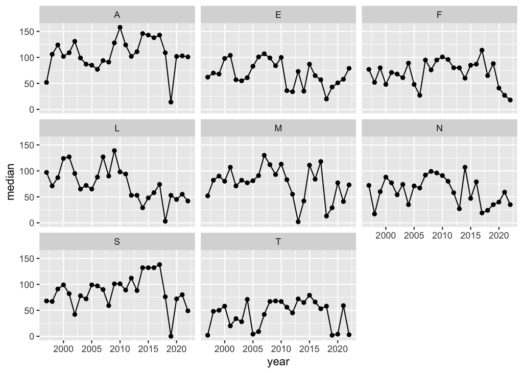

```r
plot_data <- Kplot_data_byclan %>%
  select(sim, A:T, year) %>%
  tidyr::pivot_longer(A:T) %>%
  group_by(name, year) %>%
  summarise(median = as.integer(median(value)),
            min = min(value),
            max = max(value)) %>%
  arrange(name, year) %>%
  mutate(n = 1:n())
ggplot(data = plot_data) +
  geom_line(aes(x =year, y = median)) +
  geom_point(aes(x =year, y = median)) +
  facet_wrap(facets = ~name)
```

```r
## Fit gaussian models for comparison
## Gaussian is easiest fit and can be compared with other mods.
K_model_perclan_gaussian <- fitme(median ~ year:name + name + AR1(1|n), data = plot_data, family = "poisson")
```

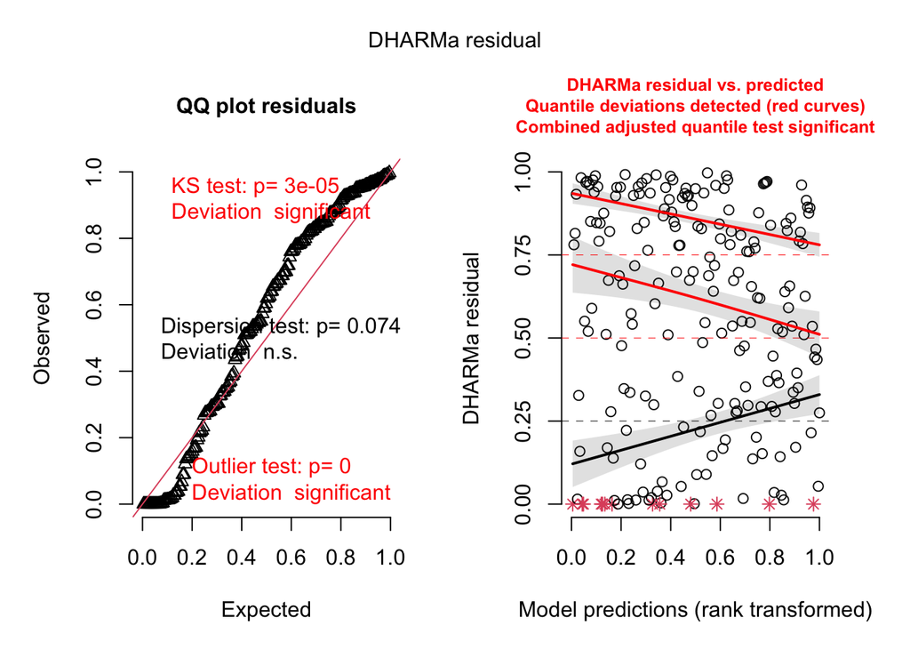

```r
K_model_perclan_gaussian_resid <- simulateResiduals(K_model_perclan_gaussian, n = 1000, seed = 123)

plot(K_model_perclan_gaussian_resid)
```

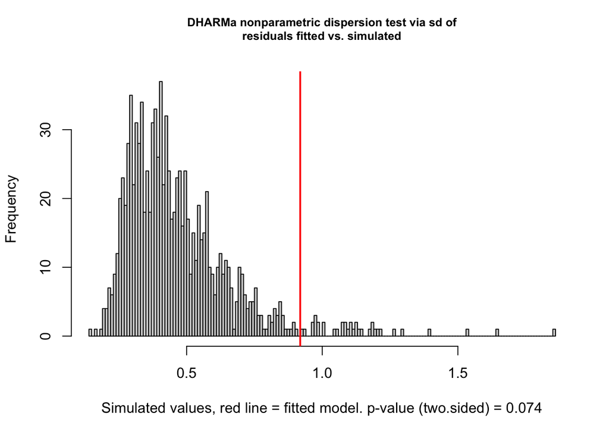

```
##
##  DHARMa nonparametric dispersion test via sd of residuals fitted vs.
##  simulated
##
## data:  simulationOutput
## dispersion = 1.9588, p-value = 0.074
## alternative hypothesis: two.sided
```

```r
DHARMa::testDispersion(K_model_perclan_gaussian_resid)
```

Dispersion issue fixed…

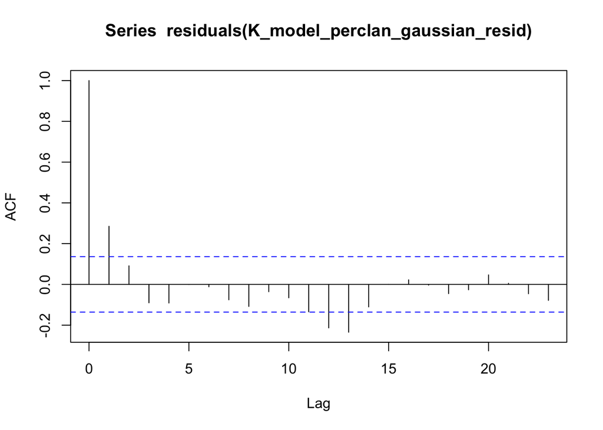

```r
acf(residuals(K_model_perclan_gaussian_resid))
```

```r
summary(K_model_perclan_gaussian)
```

```
## formula: median ~ year:name + name + AR1(1 | n)
## Estimation of corrPars and lambda by ML (p_v approximation of logL).
## Estimation of fixed effects by ML (p_v approximation of logL).
## Estimation of lambda by 'outer' ML, maximizing logL.
## family: poisson( link = log )
##  ------------ Fixed effects (beta) ------------
##              Estimate Cond. SE t-value
## (Intercept) -3.996731 22.32639 -0.1790
## nameE       47.962952  8.68774  5.5208
## nameF       17.350483  8.60433  2.0165
## nameL       90.130201  8.55187 10.5392
## nameM       45.505649  8.41185  5.4097
## nameN       44.356028  8.98118  4.9388
## nameS        3.021391  8.11101  0.3725
## nameT       -4.701269 10.09118 -0.4659
## year:nameA   0.004286  0.01111  0.3858
## year:nameE  -0.019806  0.01129 -1.7536
## year:nameF  -0.004556  0.01128 -0.4040
## year:nameL  -0.040762  0.01127 -3.6173
## year:nameM  -0.018529  0.01124 -1.6481
## year:nameN  -0.018065  0.01135 -1.5914
## year:nameS   0.002677  0.01119  0.2393
## year:nameT   0.006178  0.01158  0.5335
##  --------------- Random effects ---------------
## Family: gaussian( link = identity )
##                    --- Correlation parameters:
##   1.ARphi
## 0.5938596
##            --- Variance parameters ('lambda'):
## lambda = var(u) for u ~ Gaussian;
##    n  :  0.0592
## # of obs: 208; # of groups: n, 26
##  ------------- Likelihood values  -------------
##                         logLik
## logL       (p_v(h)): -1516.005
```

```r
global_mod <- fitme(median ~ year:name + name + AR1(1|n), data = plot_data, family = "poisson")
null_mod   <- fitme(median ~ name + AR1(1|n), data = plot_data, family = "poisson")
```

```r
## Need to bootstrap this, it takes some time
LRT(global_mod, null_mod)
```

```
##      chi2_LR df p_value
## p_v 173.6867  8       0
```

```r
# LRT_result_gaussian <- LRT(global_mod, null_mod, boot.repl = 999, nb_cores = 10, seed = 123)
# data.frame(basic = LRT_result_gaussian$basicLRT$p_value, bartlett = LRT_result_gaussian$BartBootLRT$p_value, bootstrap = LRT_result_gaussian$rawBootLRT$p_value)
```

CI of year term

```r
spaMM::confint.HLfit(global_mod, parm = "year:nameA")
```

```
## lower year:nameA upper year:nameA
##      -0.02190370       0.03211705
```

```r
spaMM::confint.HLfit(global_mod, parm = "year:nameE")
```

```
## lower year:nameE upper year:nameE
##     -0.046230048      0.008245664
```

```r
spaMM::confint.HLfit(global_mod, parm = "year:nameF")
```

```
## lower year:nameF upper year:nameF
##      -0.03094956       0.02383586
```

```r
spaMM::confint.HLfit(global_mod, parm = "year:nameL")
```

```
## lower year:nameL upper year:nameL
##      -0.06714866      -0.01277170
```

```r
spaMM::confint.HLfit(global_mod, parm = "year:nameM")
```

```
## lower year:nameM upper year:nameM
##     -0.044891671      0.009815531
```

```r
spaMM::confint.HLfit(global_mod, parm = "year:nameN")
```

```
## lower year:nameN upper year:nameN
##      -0.04454530       0.01003258
```

```r
spaMM::confint.HLfit(global_mod, parm = "year:nameS")
```

```
## lower year:nameS upper year:nameS
##      -0.02360392       0.03042070
```

```r
spaMM::confint.HLfit(global_mod, parm = "year:nameT")
```

```
## lower year:nameT upper year:nameT
##      -0.02057904       0.03458640
```

## Kt in growth period

```r
K_model_growthperiod <- fitme(globalK ~ year + AR1(1|n), data = poisson_data %>% filter(year <= growth_period_until), family = "poisson")
null_mod <- fitme(globalK ~ 1 + AR1(1|n), data = poisson_data %>% filter(year <= growth_period_until), family = "poisson")
summary(K_model_growthperiod)
```

```
## formula: globalK ~ year + AR1(1 | n)
## Estimation of corrPars and lambda by ML (p_v approximation of logL).
## Estimation of fixed effects by ML (p_v approximation of logL).
## Estimation of lambda by 'outer' ML, maximizing logL.
## family: poisson( link = log )
##  ------------ Fixed effects (beta) ------------
##             Estimate Cond. SE t-value
## (Intercept) -40.2576  20.8395  -1.932
## year          0.0233   0.0104   2.241
##  --------------- Random effects ---------------
## Family: gaussian( link = identity )
##                    --- Correlation parameters:
##   1.ARphi
## 0.3882672
##            --- Variance parameters ('lambda'):
## lambda = var(u) for u ~ Gaussian;
##    n  :  0.01599
## # of obs: 15; # of groups: n, 15
##  ------------- Likelihood values  -------------
##                         logLik
## logL       (p_v(h)): -86.60181
```

```r
## Asympototic for consistency
LRT(K_model_growthperiod, null_mod)
```

```
##      chi2_LR df    p_value
## p_v 3.364323  1 0.06662296
```

```r
# LRT_result_gaussian <- LRT(K_model_growthperiod, null_mod, boot.repl = 999, nb_cores = 10, seed = 123)
# data.frame(basic = LRT_result_gaussian$basicLRT$p_value, bartlett = LRT_result_gaussian$BartBootLRT$p_value, bootstrap = LRT_result_gaussian$rawBootLRT$p_value)
```

```r
summary(K_model_growthperiod)
```

```
## formula: globalK ~ year + AR1(1 | n)
## Estimation of corrPars and lambda by ML (p_v approximation of logL).
## Estimation of fixed effects by ML (p_v approximation of logL).
## Estimation of lambda by 'outer' ML, maximizing logL.
## family: poisson( link = log )
##  ------------ Fixed effects (beta) ------------
##             Estimate Cond. SE t-value
## (Intercept) -40.2576  20.8395  -1.932
## year          0.0233   0.0104   2.241
##  --------------- Random effects ---------------
## Family: gaussian( link = identity )
##                    --- Correlation parameters:
##   1.ARphi
## 0.3882672
##            --- Variance parameters ('lambda'):
## lambda = var(u) for u ~ Gaussian;
##    n  :  0.01599
## # of obs: 15; # of groups: n, 15
##  ------------- Likelihood values  -------------
##                         logLik
## logL       (p_v(h)): -86.60181
```

```r
confint(K_model_growthperiod, parm = "year")
```

```
##   lower year   upper year
## -0.002441133  0.049206544
```

## Ktc in growth period

```r
K_model_perclan_growthperiod <- fitme(median ~ year:name + name + AR1(1|n),
                                      data = plot_data %>% filter(year <= growth_period_until), family = "poisson")

null_mod <- fitme(median ~ name + AR1(1|n),
                  data = plot_data %>% filter(year <= growth_period_until), family = "poisson")
summary(K_model_perclan_growthperiod)
```

```
## formula: median ~ year:name + name + AR1(1 | n)
## Estimation of corrPars and lambda by ML (p_v approximation of logL).
## Estimation of fixed effects by ML (p_v approximation of logL).
## Estimation of lambda by 'outer' ML, maximizing logL.
## family: poisson( link = log )
##  ------------ Fixed effects (beta) ------------
##               Estimate Cond. SE t-value
## (Intercept) -37.800580 23.64862 -1.5984
## nameE        23.540356 17.76795  1.3249
## nameF       -15.981522 18.27387 -0.8746
## nameL        23.761815 16.85298  1.4099
## nameM        -9.507596 17.18656 -0.5532
## nameN       -36.692679 18.37406 -1.9970
## nameS         8.081599 17.57086  0.4599
## nameT       -63.196915 22.07503 -2.8628
## year:nameA    0.021172  0.01180  1.7942
## year:nameE    0.009288  0.01225  0.7584
## year:nameF    0.028961  0.01243  2.3294
## year:nameL    0.009274  0.01192  0.7780
## year:nameM    0.025839  0.01204  2.1460
## year:nameN    0.039288  0.01247  3.1504
## year:nameS    0.017021  0.01218  1.3979
## year:nameT    0.052238  0.01388  3.7623
##  --------------- Random effects ---------------
## Family: gaussian( link = identity )
##                    --- Correlation parameters:
##   1.ARphi
## 0.3859478
##            --- Variance parameters ('lambda'):
## lambda = var(u) for u ~ Gaussian;
##    n  :  0.01648
## # of obs: 120; # of groups: n, 15
##  ------------- Likelihood values  -------------
##                         logLik
## logL       (p_v(h)): -671.0246
```

```r
## Asympototic for consistency
LRT(K_model_perclan_growthperiod, null_mod)
```

```
##      chi2_LR df      p_value
## p_v 29.58577  8 0.0002501354
```

```r
# LRT_result_gaussian <- LRT(K_model_perclan_growthperiod, null_mod, boot.repl = 999, nb_cores = 10, seed = 123)
# data.frame(basic = LRT_result_gaussian$basicLRT$p_value, bartlett = LRT_result_gaussian$BartBootLRT$p_value, bootstrap = LRT_result_gaussian$rawBootLRT$p_value)
```

```r
spaMM::confint.HLfit(K_model_perclan_growthperiod, parm = "year:nameA")
```

```
## lower year:nameA upper year:nameA
##     -0.006292323      0.048589571
```

```r
spaMM::confint.HLfit(K_model_perclan_growthperiod, parm = "year:nameE")
```

```
## lower year:nameE upper year:nameE
##      -0.01866376       0.03704384
```

```r
spaMM::confint.HLfit(K_model_perclan_growthperiod, parm = "year:nameF")
```

```
## lower year:nameF upper year:nameF
##     0.0007733304     0.0571942910
```

```r
spaMM::confint.HLfit(K_model_perclan_growthperiod, parm = "year:nameL")
```

```
## lower year:nameL upper year:nameL
##      -0.01827401       0.03684458
```

```r
spaMM::confint.HLfit(K_model_perclan_growthperiod, parm = "year:nameM")
```

```
## lower year:nameM upper year:nameM
##     -0.001861522      0.053374882
```

```r
spaMM::confint.HLfit(K_model_perclan_growthperiod, parm = "year:nameN")
```

```
## lower year:nameN upper year:nameN
##       0.01104902       0.06756299
```

```r
spaMM::confint.HLfit(K_model_perclan_growthperiod, parm = "year:nameS")
```

```
## lower year:nameS upper year:nameS
##      -0.01084037       0.04462816
```

```r
spaMM::confint.HLfit(K_model_perclan_growthperiod, parm = "year:nameT")
```

```
## lower year:nameT upper year:nameT
##       0.02216581       0.08233601
```

## Kt after growth period

```r
K_model_growthperiod <- fitme(globalK ~ year + AR1(1|n), data = poisson_data %>% filter(year > growth_period_until), family = "poisson")
null_mod <- fitme(globalK ~ 1 + AR1(1|n), data = poisson_data %>% filter(year > growth_period_until), family = "poisson")
summary(K_model_growthperiod)
```

```
## formula: globalK ~ year + AR1(1 | n)
## Estimation of corrPars and lambda by ML (p_v approximation of logL).
## Estimation of fixed effects by ML (p_v approximation of logL).
## Estimation of lambda by 'outer' ML, maximizing logL.
## family: poisson( link = log )
##  ------------ Fixed effects (beta) ------------
##             Estimate Cond. SE t-value
## (Intercept) 97.48540 62.06683   1.571
## year        -0.04525  0.03077  -1.471
##  --------------- Random effects ---------------
## Family: gaussian( link = identity )
##                    --- Correlation parameters:
##  1.ARphi
## 0.349294
##            --- Variance parameters ('lambda'):
## lambda = var(u) for u ~ Gaussian;
##    n  :  0.0648
## # of obs: 11; # of groups: n, 11
##  ------------- Likelihood values  -------------
##                         logLik
## logL       (p_v(h)): -68.57744
```

```r
## Asympototic for consistency
LRT(K_model_growthperiod, null_mod)
```

```
##      chi2_LR df   p_value
## p_v 1.606648  1 0.2049637
```

```r
# LRT_result_gaussian <- LRT(K_model_growthperiod, null_mod, boot.repl = 999, nb_cores = 10, seed = 123)
# data.frame(basic = LRT_result_gaussian$basicLRT$p_value, bartlett = LRT_result_gaussian$BartBootLRT$p_value, bootstrap = LRT_result_gaussian$rawBootLRT$p_value)
```

```r
summary(K_model_growthperiod)
```

```
## formula: globalK ~ year + AR1(1 | n)
## Estimation of corrPars and lambda by ML (p_v approximation of logL).
## Estimation of fixed effects by ML (p_v approximation of logL).
## Estimation of lambda by 'outer' ML, maximizing logL.
## family: poisson( link = log )
##  ------------ Fixed effects (beta) ------------
##             Estimate Cond. SE t-value
## (Intercept) 97.48540 62.06683   1.571
## year        -0.04525  0.03077  -1.471
##  --------------- Random effects ---------------
## Family: gaussian( link = identity )
##                    --- Correlation parameters:
##  1.ARphi
## 0.349294
##            --- Variance parameters ('lambda'):
## lambda = var(u) for u ~ Gaussian;
##    n  :  0.0648
## # of obs: 11; # of groups: n, 11
##  ------------- Likelihood values  -------------
##                         logLik
## logL       (p_v(h)): -68.57744
```

```r
confint(K_model_growthperiod, parm = "year", boot_args = list(nsim = 999, nb_cores = 10, seed = 123))
```

```
## Missing 'type' in 'boot_args' is set to 'marginal'
##  (this default type has been changed in version 4.4.23).
```

```
## Bootstrap replicates:  bootstrap took 19.82 s.
## BOOTSTRAP CONFIDENCE INTERVAL CALCULATIONS
## Based on 999 bootstrap replicates
##
## CALL :
## boot.ci(boot.out = list(999, "parametric"), conf = 0.95, type = c("basic",
## "perc", "norm"), t0 = -0.0452507738260617, `str(long numeric 't')` = c(" Named num [1:999] -0.05584 -0.07911 0.00659 -0.08703 -0.03164 ...",
## " - attr(*, \"names\")= chr [1:999] \"result.1\" \"result.2\" \"result.3\" \"result.4\" ..."
## ))
##
## Intervals :
## Level      Normal              Basic              Percentile
## 95%   (-0.1085,  0.0154 )   (-0.1073,  0.0142 )   (-0.1047,  0.0168 )
## Calculations and Intervals on Original Scale
```

## Ktc after growth period

```r
K_model_perclan_growthperiod <- fitme(median ~ year:name + name + AR1(1|n),
                                      data = plot_data %>% filter(year > growth_period_until), family = "poisson")

null_mod <- fitme(median ~ name + AR1(1|n),
                  data = plot_data %>% filter(year > growth_period_until), family = "poisson")
summary(K_model_perclan_growthperiod)
```

```
## formula: median ~ year:name + name + AR1(1 | n)
## Estimation of corrPars and lambda by ML (p_v approximation of logL).
## Estimation of fixed effects by ML (p_v approximation of logL).
## Estimation of lambda by 'outer' ML, maximizing logL.
## family: poisson( link = log )
##  ------------ Fixed effects (beta) ------------
##               Estimate Cond. SE t-value
## (Intercept)   76.73946 65.23735  1.1763
## nameE       -111.66859 33.06262 -3.3775
## nameF         95.01617 31.57628  3.0091
## nameL        -64.50688 34.97477 -1.8444
## nameM       -121.72646 32.32337 -3.7659
## nameN         27.56023 34.93319  0.7889
## nameS        104.41471 28.89367  3.6138
## nameT        190.51307 36.89034  5.1643
## year:nameA    -0.03574  0.03234 -1.1050
## year:nameE     0.01928  0.03367  0.5727
## year:nameF    -0.08310  0.03332 -2.4941
## year:nameL    -0.00418  0.03414 -0.1224
## year:nameM     0.02430  0.03349  0.7256
## year:nameN    -0.04982  0.03413 -1.4594
## year:nameS    -0.08761  0.03272 -2.6780
## year:nameT    -0.13066  0.03463 -3.7726
##  --------------- Random effects ---------------
## Family: gaussian( link = identity )
##                    --- Correlation parameters:
##  1.ARphi
## 0.368554
##            --- Variance parameters ('lambda'):
## lambda = var(u) for u ~ Gaussian;
##    n  :  0.0653
## # of obs: 88; # of groups: n, 11
##  ------------- Likelihood values  -------------
##                         logLik
## logL       (p_v(h)): -710.8653
```

```r
## Asympototic for consistency
LRT(K_model_perclan_growthperiod, null_mod)
```

```
##      chi2_LR df p_value
## p_v 118.9336  8       0
```

```r
# LRT_result_gaussian <- LRT(K_model_perclan_growthperiod, null_mod, boot.repl = 999, nb_cores = 10, seed = 123)
# data.frame(basic = LRT_result_gaussian$basicLRT$p_value, bartlett = LRT_result_gaussian$BartBootLRT$p_value, bootstrap = LRT_result_gaussian$rawBootLRT$p_value)
```

```r
summary(K_model_perclan_growthperiod)
```

```
## formula: median ~ year:name + name + AR1(1 | n)
## Estimation of corrPars and lambda by ML (p_v approximation of logL).
## Estimation of fixed effects by ML (p_v approximation of logL).
## Estimation of lambda by 'outer' ML, maximizing logL.
## family: poisson( link = log )
##  ------------ Fixed effects (beta) ------------
##               Estimate Cond. SE t-value
## (Intercept)   76.73946 65.23735  1.1763
## nameE       -111.66859 33.06262 -3.3775
## nameF         95.01617 31.57628  3.0091
## nameL        -64.50688 34.97477 -1.8444
## nameM       -121.72646 32.32337 -3.7659
## nameN         27.56023 34.93319  0.7889
## nameS        104.41471 28.89367  3.6138
## nameT        190.51307 36.89034  5.1643
## year:nameA    -0.03574  0.03234 -1.1050
## year:nameE     0.01928  0.03367  0.5727
## year:nameF    -0.08310  0.03332 -2.4941
## year:nameL    -0.00418  0.03414 -0.1224
## year:nameM     0.02430  0.03349  0.7256
## year:nameN    -0.04982  0.03413 -1.4594
## year:nameS    -0.08761  0.03272 -2.6780
## year:nameT    -0.13066  0.03463 -3.7726
##  --------------- Random effects ---------------
## Family: gaussian( link = identity )
##                    --- Correlation parameters:
##  1.ARphi
## 0.368554
##            --- Variance parameters ('lambda'):
## lambda = var(u) for u ~ Gaussian;
##    n  :  0.0653
## # of obs: 88; # of groups: n, 11
##  ------------- Likelihood values  -------------
##                         logLik
## logL       (p_v(h)): -710.8653
```

```r
spaMM::confint.HLfit(K_model_perclan_growthperiod, parm = "year:nameA")
```

```
## lower year:nameA upper year:nameA
##       -0.1098040        0.0498603
```

```r
spaMM::confint.HLfit(K_model_perclan_growthperiod, parm = "year:nameE")
```

```
## lower year:nameE upper year:nameE
##      -0.05633673       0.10616054
```

```r
spaMM::confint.HLfit(K_model_perclan_growthperiod, parm = "year:nameF")
```

```
## lower year:nameF upper year:nameF
##     -0.158358158      0.003379141
```

```r
spaMM::confint.HLfit(K_model_perclan_growthperiod, parm = "year:nameL")
```

```
## lower year:nameL upper year:nameL
##      -0.08039381       0.08315054
```

```r
spaMM::confint.HLfit(K_model_perclan_growthperiod, parm = "year:nameM")
```

```
## lower year:nameM upper year:nameM
##      -0.05109799       0.11101159
```

```r
spaMM::confint.HLfit(K_model_perclan_growthperiod, parm = "year:nameN")
```

```
## lower year:nameN upper year:nameN
##      -0.12604195       0.03747837
```

```r
spaMM::confint.HLfit(K_model_perclan_growthperiod, parm = "year:nameS")
```

```
## lower year:nameS upper year:nameS
##      -0.16214737      -0.00170634
```

```r
spaMM::confint.HLfit(K_model_perclan_growthperiod, parm = "year:nameT")
```

```
## lower year:nameT upper year:nameT
##      -0.20759002      -0.04295084
```

## Sex ratio

Descriptive stats

```r
real_pop_separate %>%
  mutate(sexratio = ad_male/(ad_male + ad_fem)) %>%
  filter(lubridate::year(date) <= end_year) |>
  summarise(median = median(sexratio),
            min = min(sexratio),
            max = max(sexratio))
```

```
## # A tibble: 1 × 3
##   median   min   max
##    <dbl> <dbl> <dbl>
## 1  0.472 0.436 0.521
```

### Sex ratio mod (binomial)

```r
ratio_data <- real_pop_separate %>%
  filter(lubridate::year(date) <= end_year) |>
  filter(lubridate::month(date) %in% c(1, 7)) %>%
  mutate(n = 1:n())
sexratio_mod <- fitme(cbind(ad_male, ad_fem) ~ n, data = ratio_data, family = "binomial")
```

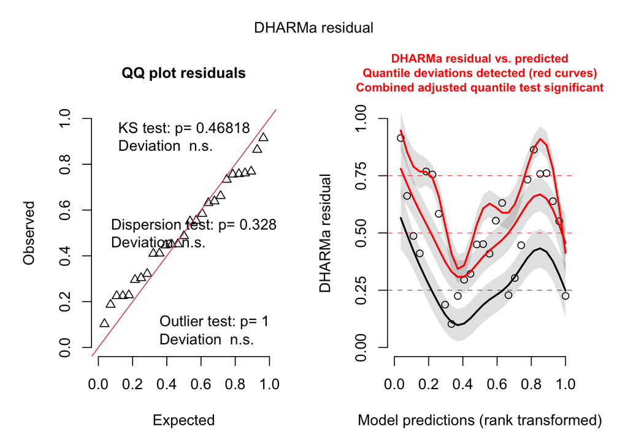

```r
sexratio_residuals <- DHARMa::simulateResiduals(sexratio_mod, n = 1000, seed = 123)
plot(sexratio_residuals)
```

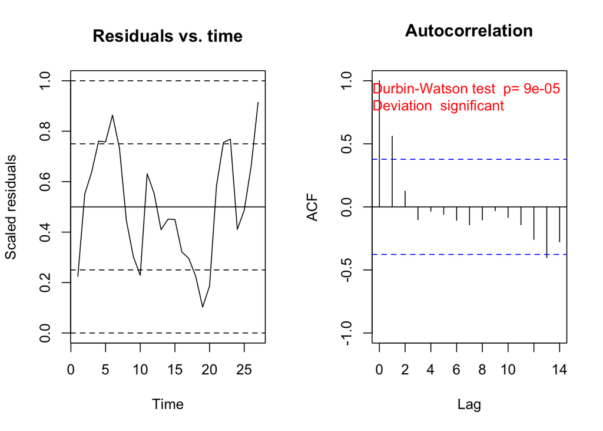

```
##
##  Durbin-Watson test
##
## data:  simulationOutput$scaledResiduals ~ 1
## DW = 0.69317, p-value = 8.642e-05
## alternative hypothesis: true autocorrelation is not 0
```

```r
testTemporalAutocorrelation(sexratio_residuals, time = 1:nrow(ratio_data))
```

### Sex ratio mod AR1 (binomial)

Do this at every 6 months to be comparable

```r
sexratio_mod2 <- fitme(cbind(ad_male, ad_fem) ~ n + AR1(1|n), data = ratio_data, family = "binomial")
summary(sexratio_mod2)
```

```
## formula: cbind(ad_male, ad_fem) ~ n + AR1(1 | n)
## Estimation of corrPars and lambda by ML (p_v approximation of logL).
## Estimation of fixed effects by ML (p_v approximation of logL).
## Estimation of lambda by 'outer' ML, maximizing logL.
## family: binomial( link = logit )
##  ------------ Fixed effects (beta) ------------
##              Estimate Cond. SE t-value
## (Intercept) -0.057074 0.055096  -1.036
## n           -0.003228 0.003174  -1.017
##  --------------- Random effects ---------------
## Family: gaussian( link = identity )
##                    --- Correlation parameters:
##   1.ARphi
## 0.6988653
##            --- Variance parameters ('lambda'):
## lambda = var(u) for u ~ Gaussian;
##    n  :  2e-06
## # of obs: 27; # of groups: n, 27
##  ------------- Likelihood values  -------------
##                         logLik
## logL       (p_v(h)): -88.10217
```

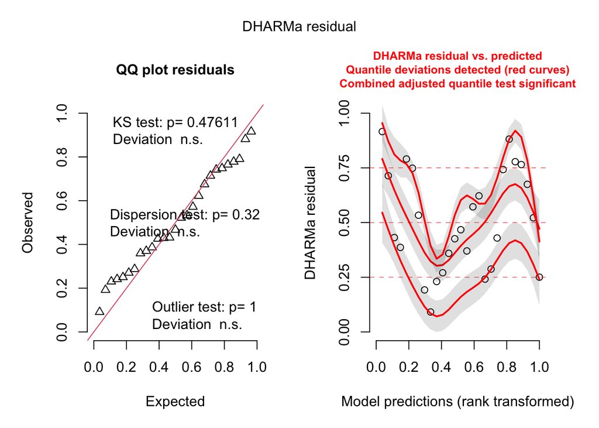

```r
sexratio2_residuals <- DHARMa::simulateResiduals(sexratio_mod2, n = 1000, seed = 123)
## Residual quantiles not great, but residuals ok w/ uniformity test
## Not sure there's much to do here when using model with so few points!
plot(sexratio2_residuals)
```

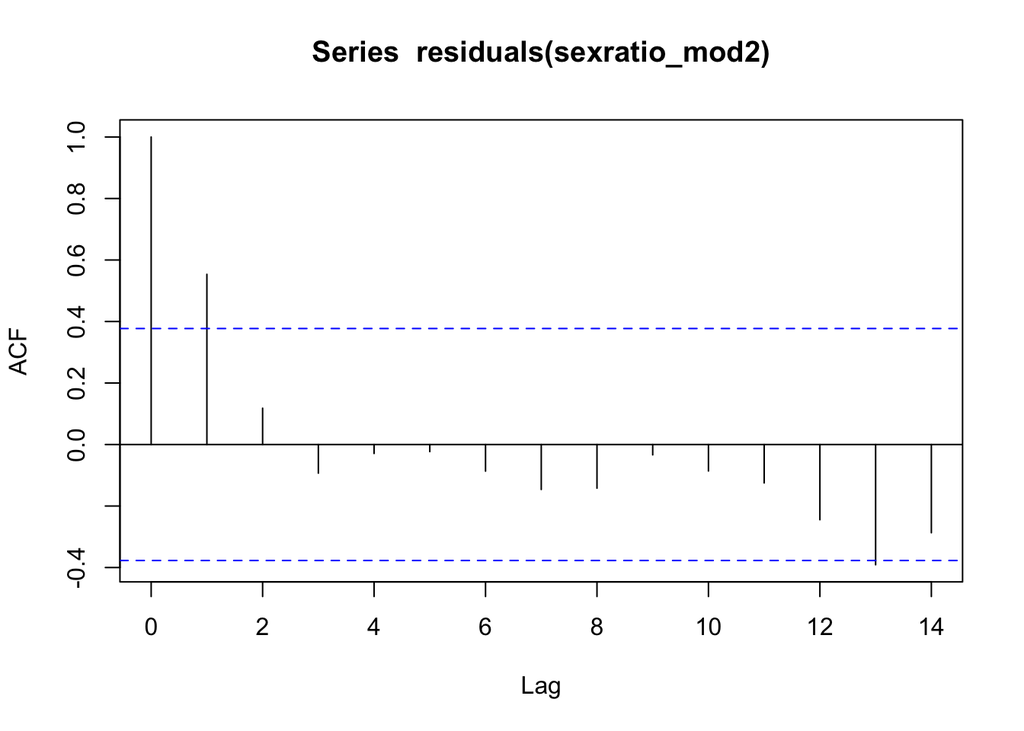

```r
acf(residuals(sexratio_mod2))
```

```r
global_mod <- fitme(cbind(ad_male, ad_fem) ~ n + AR1(1|n), data = ratio_data, family = "binomial")
null_mod   <- fitme(cbind(ad_male, ad_fem) ~ 1 + AR1(1|n), data = ratio_data, family = "binomial")

summary(global_mod)
```

```
## formula: cbind(ad_male, ad_fem) ~ n + AR1(1 | n)
## Estimation of corrPars and lambda by ML (p_v approximation of logL).
## Estimation of fixed effects by ML (p_v approximation of logL).
## Estimation of lambda by 'outer' ML, maximizing logL.
## family: binomial( link = logit )
##  ------------ Fixed effects (beta) ------------
##              Estimate Cond. SE t-value
## (Intercept) -0.057074 0.055096  -1.036
## n           -0.003228 0.003174  -1.017
##  --------------- Random effects ---------------
## Family: gaussian( link = identity )
##                    --- Correlation parameters:
##   1.ARphi
## 0.6988653
##            --- Variance parameters ('lambda'):
## lambda = var(u) for u ~ Gaussian;
##    n  :  2e-06
## # of obs: 27; # of groups: n, 27
##  ------------- Likelihood values  -------------
##                         logLik
## logL       (p_v(h)): -88.10217
```

```r
## Fails with bootstrap...is it because we're using cbind?!
LRT(global_mod, null_mod)
```

```
##      chi2_LR df   p_value
## p_v 1.034491  1 0.3091061
```

```r
confint(global_mod, parm = "n")
```

```
##      lower n      upper n
## -0.009639422  0.003880945
```

## Age ratio

Descriptive stats

```r
real_pop_separate %>%
  mutate(sexratio = young/(young + ad_male + ad_fem)) %>%
  filter(lubridate::year(date) <= end_year) |>
  summarise(median = median(sexratio),
            min = min(sexratio),
            max = max(sexratio))
```

```
## # A tibble: 1 × 3
##   median   min   max
##    <dbl> <dbl> <dbl>
## 1  0.434 0.375 0.476
```

### Age ratio mod (binomial)

Do this at every 6 months to be comparable

```r
ageratio_mod <- fitme(cbind(young, ad_male + ad_fem) ~ n, data = ratio_data, family = "binomial")
```

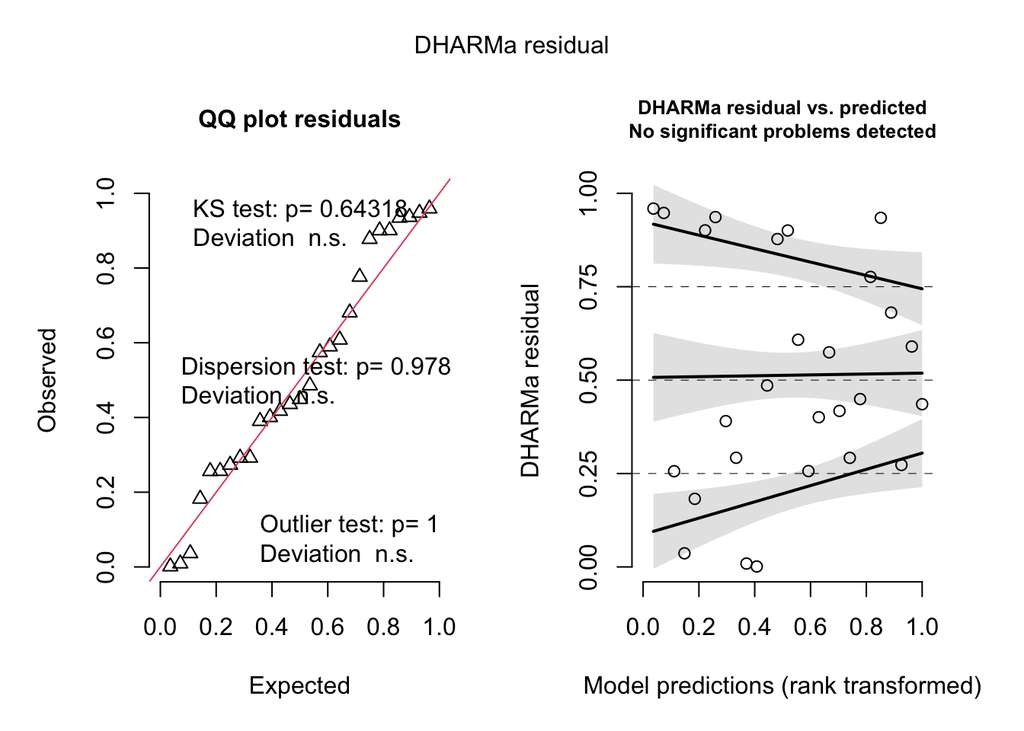

```r
ageratio_residuals <- DHARMa::simulateResiduals(ageratio_mod, n = 1000, seed = 123)
plot(ageratio_residuals)
```

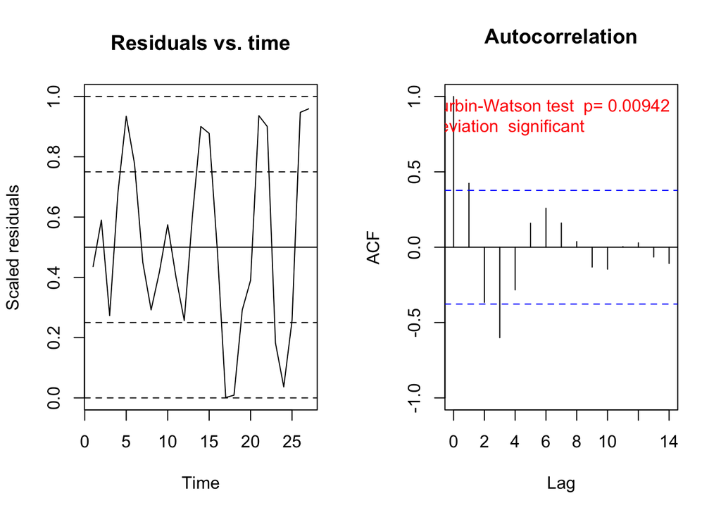

```
##
##  Durbin-Watson test
##
## data:  simulationOutput$scaledResiduals ~ 1
## DW = 1.0696, p-value = 0.009419
## alternative hypothesis: true autocorrelation is not 0
```

```r
testTemporalAutocorrelation(ageratio_residuals, time = 1:nrow(ratio_data))
```

### Age ratio mod AR1 (binomial)

Do this at every 6 months to be comparable

```r
ageratio_mod2 <- fitme(cbind(young, ad_male + ad_fem) ~ n + AR1(1|n), data = ratio_data, family = "binomial")
summary(ageratio_mod2)
```

```
## formula: cbind(young, ad_male + ad_fem) ~ n + AR1(1 | n)
## Estimation of corrPars and lambda by ML (p_v approximation of logL).
## Estimation of fixed effects by ML (p_v approximation of logL).
## Estimation of lambda by 'outer' ML, maximizing logL.
## family: binomial( link = logit )
##  ------------ Fixed effects (beta) ------------
##              Estimate Cond. SE t-value
## (Intercept) -0.237011 0.055494 -4.2709
## n           -0.002778 0.003292 -0.8436
##  --------------- Random effects ---------------
## Family: gaussian( link = identity )
##                    --- Correlation parameters:
##   1.ARphi
## 0.3989786
##            --- Variance parameters ('lambda'):
## lambda = var(u) for u ~ Gaussian;
##    n  :  0.003818
## # of obs: 27; # of groups: n, 27
##  ------------- Likelihood values  -------------
##                         logLik
## logL       (p_v(h)): -105.3411
```

```
## qu = 0.25, log(sigma) = -3.852444 : outer Newton did not converge fully.
```

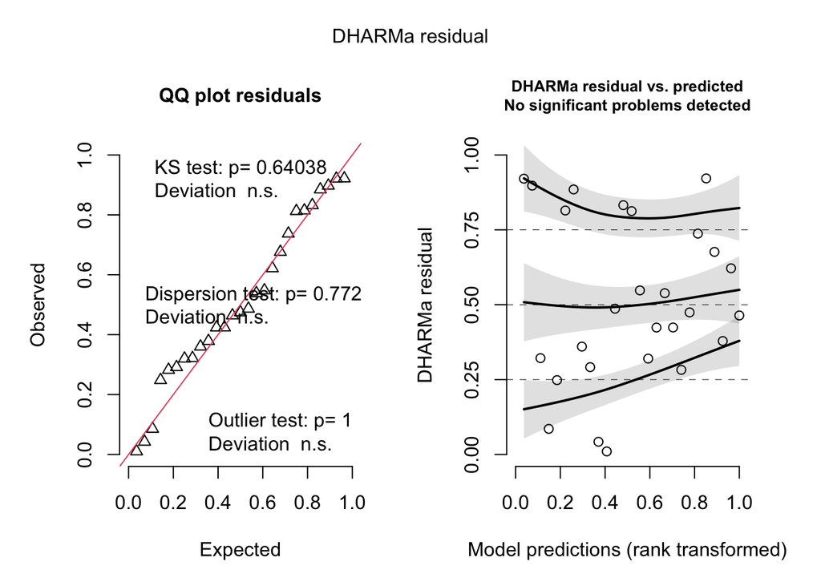

```r
ageratio2_residuals <- DHARMa::simulateResiduals(ageratio_mod2, n = 1000, seed = 123)
## AGE RATIO MODEL IS MUCH BETTER FIT
plot(ageratio2_residuals)
```

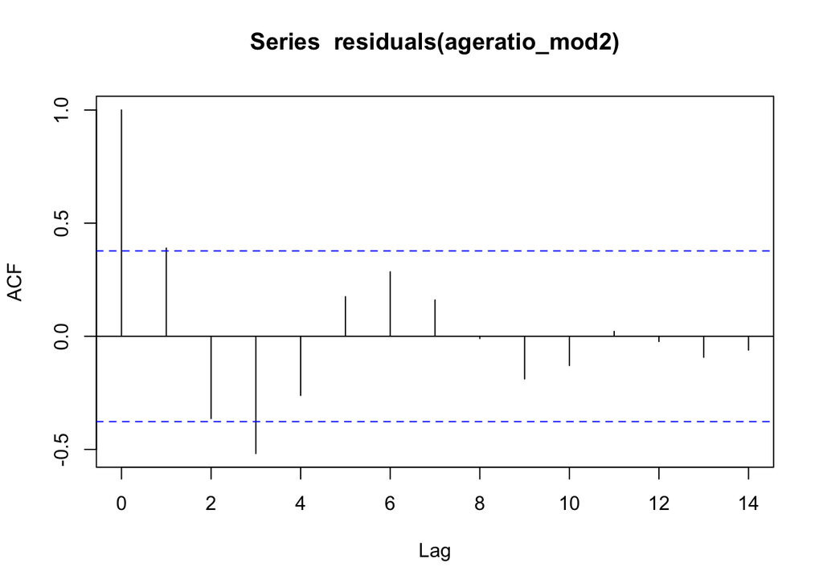

```r
acf(residuals(ageratio_mod2))
```

```r
global_mod <- fitme(cbind(young, ad_male + ad_fem) ~ n + AR1(1|n), data = ratio_data, family = "binomial")
null_mod   <- fitme(cbind(young, ad_male + ad_fem) ~ 1 + AR1(1|n), data = ratio_data, family = "binomial")

summary(global_mod)
```

```
## formula: cbind(young, ad_male + ad_fem) ~ n + AR1(1 | n)
## Estimation of corrPars and lambda by ML (p_v approximation of logL).
## Estimation of fixed effects by ML (p_v approximation of logL).
## Estimation of lambda by 'outer' ML, maximizing logL.
## family: binomial( link = logit )
##  ------------ Fixed effects (beta) ------------
##              Estimate Cond. SE t-value
## (Intercept) -0.237011 0.055494 -4.2709
## n           -0.002778 0.003292 -0.8436
##  --------------- Random effects ---------------
## Family: gaussian( link = identity )
##                    --- Correlation parameters:
##   1.ARphi
## 0.3989786
##            --- Variance parameters ('lambda'):
## lambda = var(u) for u ~ Gaussian;
##    n  :  0.003818
## # of obs: 27; # of groups: n, 27
##  ------------- Likelihood values  -------------
##                         logLik
## logL       (p_v(h)): -105.3411
```

```r
## Fails with bootstrap, because we're using cbind?
LRT(global_mod, null_mod)
```

```
##       chi2_LR df   p_value
## p_v 0.6461278  1 0.4215005
```

```r
confint(global_mod, parm = "n")
```

```
##      lower n      upper n
## -0.009755499  0.005443646
```